# CPP 528 Lab 05

Team 2

4/19/2022

## Visual models comparing Median Home Value Growth by receipt of New Market Tax Credits or Low Income Housing Tax Credits

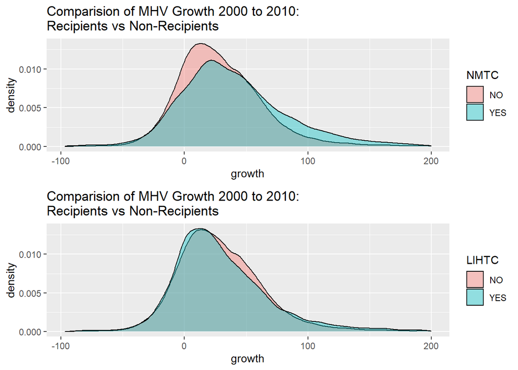

## Difference in Difference Regression for NMTC without controls

|  | *Dependent variable:* |
| --- | --- |
|  | y |
| treat.nmtc | -0.26*** |
|  | (0.02) |
| post | 0.23*** |
|  | (0.004) |
| treat.nmtc:post | 0.10*** |
|  | (0.02) |
| Constant | 11.96*** |
|  | (0.003) |
| Observations | 118,132 |
| R<sup>2</sup> | 0.04 |
| Adjusted R<sup>2</sup> | 0.04 |
| Residual Std. Error | 0.64 (df = 118128) |
| F Statistic | 1,432.34*** (df = 3; 118128) |
| *Note:* | p<0.1; p<0.05; p<0.01 |

#### Calculating results (NMTC no controls)

C1 = Control group, 2000

```
## (Intercept)
##    156581.4
```

C2 = Control group, 2010

```
## (Intercept)
##    196984.4
```

T1 = NMTC treatment, 2000

```
## (Intercept)
##    120265.3
```

T2 = NMTC treatment, 2010 (post-intervention)

```
## (Intercept)
##    166560.5
```

### NMTC results without including control variables

C1, Control group 2000 = 156581.4  
C2, Control group 2010 = 196984.4  
T1, NMTC group 2000 = 120265.3  
T2, NMTC group 2010 = 166560.5

## NMTC regression with control variables added

Variables of interest:

- Percent white residents in 2000 (p.white.00)
- Percent with 4-year college education or more (p.col.edu.00)
- Poverty rate in 2000 (pov.rate.00)

|  | *Dependent variable:* |
| --- | --- |
|  | y |
| treat.nmtc | 0.05*** |
|  | (0.01) |
| post | 0.23*** |
|  | (0.003) |
| p.white | -0.005*** |
|  | (0.0001) |
| p.col.edu.00 | 0.02*** |
|  | (0.0001) |
| pov.rate.00 | -0.02*** |
|  | (0.0002) |
| treat.nmtc:post | 0.10*** |
|  | (0.02) |
| Constant | 11.92*** |
|  | (0.01) |
| Observations | 118,132 |
| R<sup>2</sup> | 0.46 |
| Adjusted R<sup>2</sup> | 0.46 |
| Residual Std. Error | 0.48 (df = 118125) |
| F Statistic | 17,047.96*** (df = 6; 118125) |
| *Note:* | p<0.1; p<0.05; p<0.01 |

#### Calculating results (NMTC *with* controls)

C1, Control group 2000

```
## (Intercept)
##    149646.6
```

C2, Control group 2010

```
## (Intercept)
##    188260.2
```

T1, NMTC group 2000 (pre-intervention)

[output not shown]

T2, NMTC group 2010 (post-intervention)

[output not shown]

## Difference in Difference Regression for LIHTC without controls

|  | *Dependent variable:* |
| --- | --- |
|  | y |
| treat.lihtc | -0.21*** |
|  | (0.01) |
| post | 0.23*** |
|  | (0.004) |
| treat.lihtc:post | 0.01 |
|  | (0.01) |
| Constant | 11.98*** |
|  | (0.003) |
| Observations | 118,132 |
| R<sup>2</sup> | 0.04 |
| Adjusted R<sup>2</sup> | 0.04 |
| Residual Std. Error | 0.64 (df = 118128) |
| F Statistic | 1,799.55*** (df = 3; 118128) |
| *Note:* | p<0.1; p<0.05; p<0.01 |

#### Calculating results (LIHTC no controls)

C1, Control group 2000

```
## (Intercept)
##    159936.6
```

C2, Control group 2010

```
## (Intercept)
##    201589.5
```

T1, LIHTC group 2000 (pre-intervention)

```
## (Intercept)
##    129977.4
```

T2, LIHTC group 2010 (post-intervention)

```
## (Intercept)
##    164796.4
```

### LIHTC results without control variables

In this model, which does not include any control variables, the Low Income Housing Tax Credit program did not have a significant effect on median home values.

## LIHTC Regression with control variables added

Variables of interest:

- Percent white residents in 2000 (p.white.00)
- Percent with 4-year college education or more (p.col.edu.00)
- Poverty rate in 2000 (pov.rate.00)

|  | *Dependent variable:* |
| --- | --- |
|  | y |
| treat.lihtc | 0.003 |
|  | (0.01) |
| post | 0.23*** |
|  | (0.003) |
| p.white | -0.005*** |
|  | (0.0001) |
| p.col.edu.00 | 0.02*** |
|  | (0.0001) |
| pov.rate.00 | -0.02*** |
|  | (0.0002) |
| treat.lihtc:post | 0.01 |
|  | (0.01) |
| Constant | 11.91*** |
|  | (0.01) |
| Observations | 118,132 |
| R<sup>2</sup> | 0.46 |
| Adjusted R<sup>2</sup> | 0.46 |
| Residual Std. Error | 0.48 (df = 118125) |
| F Statistic | 16,999.84*** (df = 6; 118125) |
| *Note:* | p<0.1; p<0.05; p<0.01 |

#### Calculating results (LIHTC *with* controls)

C1, Control group 2000

```
## (Intercept)
##    149295.7
```

C2, Control group 2010

```
## (Intercept)
##    188177.2
```

T1, LIHTC group 2000 (pre-intervention)

```
## (Intercept)
##    149733.1
```

T2, LIHTC group 2010 (post-intervention)

```
## (Intercept)
##    187813.8
```

### LIHTC results with control variables

When percent white residents, percent of college educated residents, and poverty rate in 2000 are included as controls, Low Income Housing Tax Credits did not have a significant effect on median home values. In this model, median home price is nearly identical in tracts with or without LIHTC.

### Reflection: How can we test the parallel lines assumption in this model?

Examining longitudinal data from points before and/or after the timeframe in question would provide evidence that the parallel trends assumption is met, that both the treatment and control groups would have changed at the same rate in the absence of the treatment.